# STA305/1004 - Class 7

January 30, 2017

# Today’s Class

- Case study on power poses study: study replication and power
- Sample size and power in studies with two proportions
- Calculating power via simulation
- Introduction to causal inference

# Can power poses significantly change outcomes in your life?

Professor Amy Cuddy

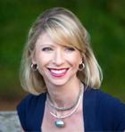

# Can power poses significantly change outcomes in your life?

Cuddy’s study methods:

- Randomly assigned 42 participants to the high-power pose or the low-power-pose condition.
- Participants believed that the study was about the science of physiological recordings and was focused on how placement of electrocardiography electrodes above and below the heart could influence data collection.
- Participants’ bodies were posed by an experimenter into high-power or low-power poses. Each participant held two poses for 1 min each.
- Participants’ risk taking was measured with a gambling task; feelings of power were measured with self-reports.
- Saliva samples, which were used to test cortisol and testosterone levels, were taken before and approximately 17 min after the power-pose manipulation.

(Carney, Cuddy, Yap, 2010)

# Can power poses significantly change outcomes in your life?

Cuddy’s study results:

> As hypothesized, high-power poses caused an increase in testosterone compared with low-power poses, which caused a decrease in testosterone, F(1, 39) = 4.29, p < .05; r = .34. Also as hypothesized, high-power poses caused a decrease in cortisol compared with low-power poses, which caused an increase in cortisol, F(1, 38) = 7.45, p < .02; r = .43

# Can power poses significantly change outcomes in your life?

- The study was replicated by Ranehill et al. (2015)
- An initial power analysis based on the effect sizes in Carney et al. (power = 0.8, $\alpha = .05$) indicated that a sample size of 100 participants would be suitable.

```r
library(pwr)
pwr.t.test(d=0.6,power = 0.8)
```

```
     Two-sample t test power calculation

              n = 44.58579
              d = 0.6
      sig.level = 0.05
          power = 0.8
    alternative = two.sided

NOTE: n is number in *each* group
```

# Can power poses significantly change outcomes in your life?

- Ranehill et al. study used a sample of 200 participants to increase reliability.
- This study found none of the significant differences found in Cuddy’s study.
- The replication study obtained very precise estimates of the effects.
- What happened?

# Can power poses significantly change outcomes in your life?

- Sampling theory predicts that the variation between samples is proportional to $\frac{1}{\sqrt n}$.
- In small samples we can expect variability.
- Many researchers often expect that these samples will be more similar than sampling theory predicts.

# Study replication

Suppose that you have run an experiment on 20 subjects, and have obtained a significant result from a two-sided z-test ($H_0: \mu=0 \mbox{ vs.} H_1:\mu \ne 0$) which confirms your theory ($z=2.23$, $p<0.05$, two-tailed). The researcher is planning to run the same experiment on an additional 10 subjects. What is the probability that the results will be significant at the 5% level by a one-tailed test ($H_1:\mu>0$), seperately for this group?

# Comparing Proportions for Binary Outcomes

- In many clinical trials, the primary endpoint is dichotomous, for example, whether a patient has responded to the treatment, or whether a patient has experienced toxicity.
- Consider a two-arm randomized trial with binary outcomes. Let $p_1$ denote the response rate of the experimental drug, $p_2$ as that of the standard drug, and the difference is $\theta= p_1 — p_2$.

# Comparing Proportions for Binary Outcomes

Let $Y_{ik}$ be the binary outcome for subject $i$ in arm $k$; that is,

$$Y_{ik} = \left\{
\begin{array}{ll}
1 & \mbox{with probability } p_k \\
0 & \mbox{with probability } 1-p_k,
\end{array}
\right.$$

for $i=1,...,n_k$ and $k=1,2$. The sum of indendent and identically distributed Bernoulli random varaibles has a binomial distribution,

$$\sum_{i=1}^{n_k} Y_{ik} \sim Bin(n_k,p_k), \thinspace k=1,2.$$

(Yin, pg. 173-174)

# Comparing Proportions for Binary Outcomes

The sample proportion for group $k$ is

$${\hat p}_k={\bar Y}_k = (1/n_k)\sum_{i=1}^{n_k} Y_{ik}, \thinspace k=1,2,$$

and $E\left( {\bar Y}_k\right)=p_k$ and $Var\left({\bar Y}_k \right)=\frac{p_k(1-p_k)}{n_k}$.

The goal of the clinical trial is to determine if there is a difference between the two groups using a binary endpoint. That is we want to test $H_0: \theta=0$ versus $H_0: \theta \ne 0.$

The test statistic (assuming that $H_0$ is true) is:

$$T = \frac {{\hat p}_1-{\hat p}_2} {\sqrt{p_1(1-p_1)/n_1+p_2(1-p_2)/n_2}} \sim N(0,1),$$

# Comparing Proportions for Binary Outcomes

The test rejects at level $\alpha$ if and only if

$$\left|T\right| \ge z_{\alpha/2}.$$

Using the same argument as the case with continuous endpoints and ignoring terms smaller than $\alpha/2$ we can solve for $\beta$

$$\beta \approx \Phi\left( z_{\alpha/2}- \frac{|\theta_1|}{\sqrt{p_1(1-p_1)/n_1+p_2(1-p_2)/n_2}} \right).$$

# Comparing Proportions for Binary Outcomes

Using this formula to solve for sample size. If $n_1=r \cdot n_2$ then

$$n_2= \frac {\left(z_{\alpha/2}+z_{\beta}\right)^2}{\theta^2} \left(p_1(1-p_1)/r+p_2(1-p_2) \right).$$

# Comparing Proportions for Binary Outcomes

```r
power.prop.test(p1 = 0.2,p2 = 0.25,power = 0.8)
```

```
     Two-sample comparison of proportions power calculation

              n = 1093.739
             p1 = 0.2
             p2 = 0.25
      sig.level = 0.05
          power = 0.8
    alternative = two.sided

NOTE: n is number in *each* group
```

# Calculating Power by Simulation

- If the test statistic and distribution of the test statistic are known then the power of the test can be calculated via simulation.
- Consider a two-sample t-test with 30 subjects per group and the standard deviation of the clinical outcome is known to be 1.
- What is the power of the test $H_0:\mu_1-\mu_2=0$ versus $H_0:\mu_1-\mu_2=0.5$, at the 5% significance level?
- The power is the proportion of times that the test correctly rejects the null hypothesis in repeated sampling.

# Calculating Power by Simulation

We can simulate a single study using the `rnorm()` command. Let’s assume that $n_1=n_2=30, \mu_1=3.5, \mu_2=3, \sigma=1, \alpha=0.05$.

```r
set.seed(2301)
t.test(rnorm(30,mean=3.5,sd=1),rnorm(30,mean=3,sd=1),var.equal = T)
```

```
    Two Sample t-test

data:  rnorm(30, mean = 3.5, sd = 1) and rnorm(30, mean = 3, sd = 1)
t = 2.1462, df = 58, p-value = 0.03605
alternative hypothesis: true difference in means is not equal to 0
95 percent confidence interval:
 0.03458122 0.99248595
sample estimates:
mean of x mean of y
 3.339362  2.825828
```

Should you reject $H_0$?

# Calculating Power by Simulation

- Suppose that 10 studies are simulated.
- What proportion of these 10 studies will reject the null hypothesis at the 5% level?
- To investigate how many times the two-sample t-test will reject at the 5% level the `replicate()` command will be used to generate 10 studies and calculate the p-value in each study.
- It will still be assumed that $n_1=n_2=30, \mu_1=3.5, \mu_2=3, \sigma=1, \alpha=0.05$.

```r
set.seed(2301)
pvals <- replicate(10,t.test(rnorm(30,mean=3.5,sd=1),
                             rnorm(30,mean=3,sd=1),
                             var.equal = T)$p.value)
pvals # print out 10 p-values
```

```
 [1] 0.03604893 0.15477655 0.01777959 0.40851999 0.34580930 0.11131007
 [7] 0.14788381 0.00317709 0.09452230 0.39173723
```

```r
#power is the number of times the test rejects at the 5% level
sum(pvals<=0.05)/10
```

```
[1] 0.3
```

# Calculating Power by Simulation

But, since we only simulated 10 studies the estimate of power will have a large standard error. So let’s try simulating 10,000 studies so that we can obtain a more precise estimate of power.

```r
set.seed(2301)
pvals <- replicate(10000,t.test(rnorm(30,mean=3.5,sd=1),
                                rnorm(30,mean=3,sd=1),
                             var.equal = T)$p.value)
sum(pvals<=0.05)/10000
```

```
[1] 0.4881
```

# Calculating Power by Simulation

This is much closer to the theoretical power obtained from `power.t.test()`.

```r
power.t.test(n = 30,delta = 0.5,sd = 1,sig.level = 0.05)
```

```
     Two-sample t test power calculation

              n = 30
          delta = 0.5
             sd = 1
      sig.level = 0.05
          power = 0.477841
    alternative = two.sided

NOTE: n is number in *each* group
```

# Calculating Power by Simulation

- The built-in R functions `power.t.test()` and `power.prop.test()` don’t have an option for calculating power where the there is unequal allocation of subjects between groups.
- These built-in functions don’t have an option to investigate power if other assumptions don’t hold (e.g., normality).
- One option is to simulate power for the scenarios that are of interest. Another option is to write your own function using the formula derived above.

# Calculating Power by Simulation

# Calculating Power by Simulation

- The number of subjects in the experimental arm that have a positive response to treatment will be an observation from a $Bin(1500,0.28)$.
- The number of subjects that have a positive response to the standard treatment will be an observation from a $Bin(500,0.2)$.
- We can obtain simulated responses from these distributions using the `rbinom()` command in R.

```r
set.seed(2301)
rbinom(1,1500,0.28)
```

```
[1] 403
```

```r
rbinom(1,500,0.20)
```

```
[1] 89
```

# Calculating Power by Simulation

- The p-value for this simulated study can be obtained using `prop.test()`.

```r
set.seed(2301)
prop.test(x=c(rbinom(1,1500,0.28),rbinom(1,500,0.20)),
          n=c(1500,500),correct = F)
```

```
    2-sample test for equality of proportions without continuity
    correction

data:  c(rbinom(1, 1500, 0.28), rbinom(1, 500, 0.2)) out of c(1500, 500)
X-squared = 16.62, df = 1, p-value = 4.568e-05
alternative hypothesis: two.sided
95 percent confidence interval:
 0.05032654 0.13100680
sample estimates:
   prop 1    prop 2
0.2686667 0.1780000
```

# Calculating Power by Simulation

- A power simulation repeats this process a large number of times.
- In the example below we simulate 10,000 hypothetical studies to calculate power.

```r
set.seed(2301)
pvals <- replicate(10000,
prop.test(x=c(rbinom(n = 1,size = 1500,prob = 0.25),
              rbinom(n=1,size=500,prob=0.20)),
              n=c(1500,500),correct=F)$p.value)
sum(pvals<=0.05)/10000
```

```
[1] 0.6231
```

If the researchers decide to have a 3:1 allocation ratio of patients in the treatment to control arm then the power will be _____?

# Introduction to causal inference - Bob’s headache

- Suppose Bob, at a particular point in time, is contemplating whether or not to take an aspirin for a headache.
- There are two treatment levels, taking an aspirin, and not taking an aspirin.
- If Bob takes the aspirin, his headache may be gone, or it may remain, say, an hour later; we denote this outcome, which can be either “Headache” or “No Headache,” by $Y(\text{Aspirin})$.
- Similarly, if Bob does not take the aspirin, his headache may remain an hour later, or it may not; we denote this potential outcome by $Y(\text{No Aspirin})$, which also can be either “Headache,” or “No Headache.”
- There are therefore two potential outcomes, $Y(\text{Aspirin})$ and $Y(\text{No Aspirin})$, one for each level of the treatment. The causal effect of the treatment involves the comparison of these two potential outcomes.

# Introduction to causal inference - Bob’s headache

Because in this example each potential outcome can take on only two values, the unit- level causal effect – the comparison of these two outcomes for the same unit – involves one of four (two by two) possibilities:

1. Headache gone only with aspirin: Y(Aspirin) = No Headache, Y(No Aspirin) = Headache
2. No effect of aspirin, with a headache in both cases: Y(Aspirin) = Headache, Y(No Aspirin) = Headache
3. No effect of aspirin, with the headache gone in both cases: Y(Aspirin) = No Headache, Y(No Aspirin) = No Headache
4. Headache gone only without aspirin: Y(Aspirin) = Headache, Y(No Aspirin) = No Headache

# Introduction to causal inference - Bob’s headache

There are two important aspects of this definition of a causal effect.

1. The definition of the causal effect depends on the potential outcomes, but it does not depend on which outcome is actually observed.
2. The causal effect is the comparison of potential outcomes, for the same unit, at the same moment in time post-treatment.
- The causal effect is not defined in terms of comparisons of outcomes at different times, as in a before-and-after comparison of my headache before and after deciding to take or not to take the aspirin.

# The fundemental problem of causal inference

“The fundamental problem of causal inference” (Holland, 1986, p. 947) is the problem that at most one of the potential outcomes can be realized and thus observed.

- If the action you take is Aspirin, you observe $Y(\text{Aspirin})$ and will never know the value of $Y(\text{No Aspirin})$ because you cannot go back in time.
- Similarly, if your action is No Aspirin, you observe $Y(\text{No Aspirin})$ but cannot know the value of $Y(\text{Aspirin})$.
- In general, therefore, even though the unit-level causal effect (the comparison of the two potential outcomes) may be well defined, by definition we cannot learn its value from just the single realized potential outcome.

# The fundemental problem of causal inference

The outcomes that would be observed under control and treatment conditions are often called **counterfactuals** or **potential outcomes**.

- If Bob took asprin for his headache then he would be assigned to the treatment condition so $T_i = 1$.
- Then $Y(\text{Aspirin})$ is observed and $Y(\text{No Aspirin})$ is the unobserved counterfactual outcome—it represents what would have happened to Bob if he had no taken aspirin.
- Conversely, if Bob had not taken aspirin then $Y(\text{No Aspirin})$ is observed and $Y(\text{Aspirin})$ is counterfactual.
- In either case, a simple treatment effect for Bob can be defined as
  $$\mbox{treatment effect for Bob }= Y(\text{Aspirin})-Y(\text{No Aspirin}).$$

# The assignment mechanism

- Suppose that a doctor prescribes surgery (labeled 1) or drug (labeled 0) for a certain condition.
- The doctor knows enough about the potential outcomes of the patients so assigns each patient the treatment that is more beneficial to that patient.

| unit | $Y_i(0)$ | $Y_i(1)$ | $Y_i(1) - Y_i(0)$ |
| --- | --- | --- | --- |
| patient #1 | 1 | 7 | 6 |
| patient #2 | 6 | 5 | -1 |
| patient #3 | 1 | 5 | 4 |
| patient #4 | 8 | 7 | -1 |
| Average | 4 | 6 | 2 |

$Y$ is years of post-treatment survival.

# The assignment mechanism

- Patients 1 and 3 will receive surgery and patients 2 and 4 will receive drug treatment.
- The observed treatments and outcomes are in this table.

| unit | $T_i$ | $Y_i^{obs}$ |
| --- | --- | --- |
| patient #1 | 1 | 7 |
| patient #2 | 0 | 6 |
| patient #3 | 1 | 5 |
| patient #4 | 0 | 8 |
| **Average Drug** |  | **7** |
| **Average Surg** |  | **6** |

- This shows that we can reach invalid conclusions if we look at the observed values of potential outcomes without considering how the treatments were assigned.